# opendataes

23 de Noviembre del 2018

## Hace mucho tiempo….

Queriamos hacer una liberia para acceder los datos de Barcelona: http://opendata-ajuntament.barcelona.cat/

Después Madrid… https://datos.madrid.es/

Después Sevilla… https://datosabiertos.sevilla.org/

Que? Y cuantas ciudades están publicando sus datos? CASI TODAS!

## datos.gob.es

- datos.gob.es es un agregador de datos de instituciones públicas en España
- Estos datos incluyen información a nivel estatal, pero también autonómico y local.
- Estamos hablando de alrededor de 19.000 datasets de temas como economía, contaminación, etc..

Por suerte…. TIENE UNA API!

## datos.gob.es

Yo creo que todavía no entienden la magnitud de los datos….

[figure not shown]

## datos.gob.es

No, en serio….

[figure not shown]

## opendataes

- `opendataes` es un paquete que pretende interactuar con la API de datos.gob.es.
- Pertence al grupo de paquetes [rOpenSpain](https://ropenspain.es/):

Y como funciona? Veamos un ejemplo.

## opendataes - Demo

[figure not shown]

## opendataes - Ejemplo

http://datos.gob.es/es/catalogo/l01080193-elecciones-al-parlamento-europeo-sobre-electores

```r
remotes::install_github("ropenspain/opendataes") # Instalamos el paquete
```

```r
library(opendataes)
path_id <- "l01080193-elecciones-al-parlamento-europeo-sobre-electores" # End path de la URL
elections <- cargar_datos(path_id, encoding = 'latin1') # Leemos los datos

elections
```

```
## <datos.gob.es API>
##    Description: Elecciones al Parlamento Europeo. % sobre electores
##    Publisher: Ayuntamiento de Barcelona
##    Languages: es, ca, en
##    Date of release: 2013-03-13 23:00:00
##    # of files read: 2 out of 2
```

## ¿Qué devuelve `cargar_datos`? (I)

```r
elections$metadata
```

```
## # A tibble: 3 x 8
##   keywords language description url   date_issued         date_modified
##   <chr>    <chr>    <chr>       <chr> <dttm>              <chr>
## 1 Año 200~ es       Elecciones~ http~ 2013-03-13 23:00:00 No modificat~
## 2 Año 200~ ca       Eleccions ~ http~ 2013-03-13 23:00:00 No modificat~
## 3 Año 200~ en       European P~ http~ 2013-03-13 23:00:00 No modificat~
## # ... with 2 more variables: publisher <chr>, publisher_data_url <chr>
```

## ¿Qué devuelve `cargar_datos`? (II)

```r
head(elections$data[[1]], 5)
```

```
## # A tibble: 5 x 14
##     Dte Barris Participacio Abstencio ERCNECat CIU   ICVEUIA   PSC    PP
##   <int> <chr>         <dbl>     <dbl>    <dbl> <chr>   <dbl> <dbl> <dbl>
## 1    NA BARCE~          510       490      110 10,6       64    62    61
## 2     1 1. el~          375       625       75 5,1        55    63    41
## 3     1 2. el~          417       583       94 7,1        68    50    36
## 4     1 3. la~          367       633      104 5,4        42    57    33
## 5     1 4. Sa~          431       569       85 6,6        77    55    41
## # ... with 5 more variables: Cs <dbl>, PODEMOS <chr>, Altres <dbl>,
## #   Blancs <chr>, Nuls <chr>
```

## Que puedo leer?

- `opendataes` es un proyecto muy ambicioso pero con muchas limitaciones.
- Solo se pueden los publishers que están en `publishers_available`.

```r
publishers_available
```

```
## # A tibble: 1 x 2
##   publishers                publisher_code
##   <chr>                     <chr>
## 1 Ayuntamiento de Barcelona l01080193
```

- Solo se pueden leer los formatos que están en `permitted_formats`.

```r
permitted_formats
```

```
## [1] "csv"
```

Porque estas grandes limitaciones?

## opendataes: workflow

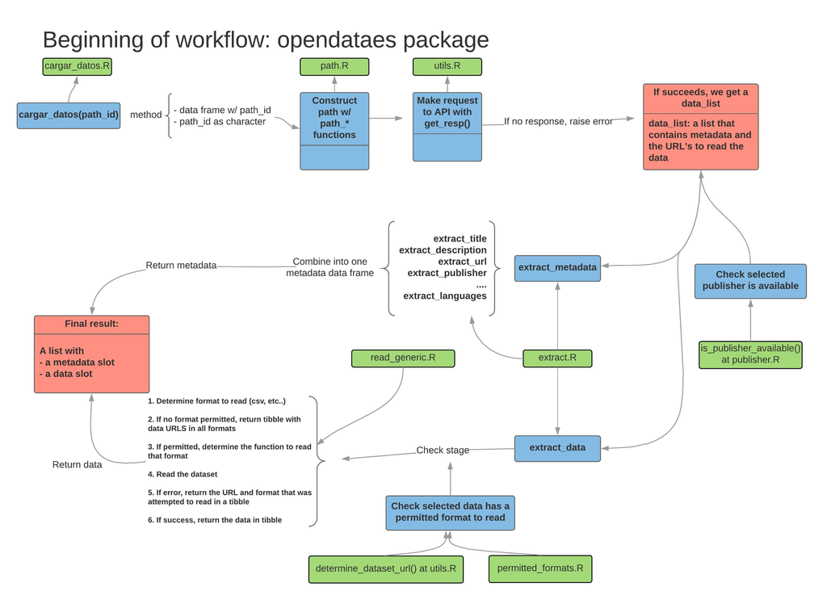

## opendataes se puede escalar?

Puedo leer muchos datos juntos? Si! `opendataes` te permite explorar los datos a través de R.

- En primer lugar, vemos los publicadores disponibles a través de `publishers_available`. Filtramos por el Ayto. de Barcelona y exploramos los *keywords*:

```r
pb_code <- publishers_available$publisher_code[publishers_available$publishers ==
                                                 'Ayuntamiento de Barcelona']
kw <- explorar_keywords('elecciones', pb_code)
head(kw, 3)
```

```
## # A tibble: 3 x 5
##   description         publisher    is_readable path_id       url
##   <chr>               <chr>        <lgl>       <chr>         <chr>
## 1 Elecciones al Parl~ Ayuntamient~ TRUE        l01080193-el~ http://datos~
## 2 Elecciones al Parl~ Ayuntamient~ TRUE        l01080193-el~ http://datos~
## 3 Elecciones al Parl~ Ayuntamient~ TRUE        l01080193-el~ http://datos~
```

## opendataes se puede escalar? (continuación)

- `cargar_datos` requiere de un dataframe con solo una fila, por lo que tendremos que seleccionar solo aquella fila que deseamos:

```r
final_dt <- kw[grepl("Elecciones Locales. Absolutos", kw$description), ]
elections <- cargar_datos(final_dt, encoding = 'latin1')
elections
```

```
## <datos.gob.es API>
##    Description: Elecciones Locales. Absolutos
##    Publisher: Ayuntamiento de Barcelona
##    Languages: es, ca, en
##    Date of release: 2013-03-13 23:00:00
##    # of files read: 3 out of 3
```

## ¿Qué devuelve `cargar_datos`? (I)

1. Los datos (si pudieron ser leídos).

```r
head(elections$data[[1]], 5)
```

```
## # A tibble: 5 x 10
##     DTE BARRIS ELECTORS VOTANTS `PSC-PM`    CIU     PP `ICV-EUIA-EPM`
##   <int> <chr>     <dbl>   <dbl>    <dbl>  <dbl>  <dbl>          <dbl>
## 1     1 1. el~     27.0    9.57     3.34   1.64   1.45           1.17
## 2     1 2. el~     11.1    4.45     1.30 969    525            681
## 3     1 3. la~     10.7    4.30     1.58 789    486            369
## 4     1 4. Sa~     14.1    6.32     1.91   1.36 808            958
## 5     2 5. el~     22.9   12.8      3.25   3.72   1.83           1.24
## # ... with 2 more variables: `ERC-AM` <dbl>, `ALTRES(UN)` <dbl>
```

## ¿Qué devuelve `cargar_datos`? (II)

2. Metadata relativa a los mismos.

```r
elections$metadata
```

```
## # A tibble: 3 x 8
##   keywords language description url   date_issued         date_modified
##   <chr>    <chr>    <chr>       <chr> <dttm>              <chr>
## 1 Absolut~ es       Elecciones~ http~ 2013-03-13 23:00:00 No modificat~
## 2 Absolut~ ca       Eleccions ~ http~ 2013-03-13 23:00:00 No modificat~
## 3 Absolut~ en       Local Elec~ http~ 2013-03-13 23:00:00 No modificat~
## # ... with 2 more variables: publisher <chr>, publisher_data_url <chr>
```

## Colaboración

- ¡Este paquete está plenamente abierto a colaboración!
- Nuestra idea es que el package paulatinamente lea archivos de más publicadores y en más formatos.
- Como colaboro? https://github.com/ropenspain/opendataes
- Leer **ambos** vignettes en la página del paquete: https://ropenspain.github.io/opendataes/
- Abrir issues en la página de Github: https://github.com/ropenspain/opendataes/issues
- Clonar el paquete desde GH y hacer un pull request: https://github.com/ropenspain/opendataes/pulls

## Estamos live!

Estamos intentando leer todos los datos de Madrid y Murcia para incluirlos como publishers!

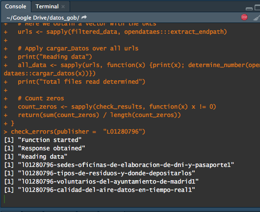